# Initial Setup

First we load the packages we will be needing.

```python
# for computation
import numpy as np
from scipy.integrate import odeint

# for visualisation
from mpl_toolkits import mplot3d

# %matplotlib inline
import matplotlib.pyplot as plt

# for autocorrelation
import scipy.signal
```

We also define a function to visualise generated data in R3 that will be used for both the L63 and Roessler systems.

```python
def plot_states(sim_data):
    fig = plt.figure(facecolor="white")
    ax = plt.axes(projection="3d")
    ax.plot(
        sim_data[:, 0],     # all x components
        sim_data[:, 1],     # all y components
        sim_data[:, 2]      # all z components
    )
    plt.draw()
    plt.show()
```

# Lorenz-63 System

Recall that the Lorenz-63 system is defined as:

$$ \begin{align*} \dot{x} &= \sigma(y - x) \\ \dot{y} &= x(\rho - z) - y \\ \dot{z} &= xy - \beta z \end{align*} $$

where $\sigma,\,\rho,\,\beta \in \mathbb{R}$ are parameters and $(x,\,y,\,z) \in \mathbb{R}^3$.

### Generating Data

We define a function to generate data for the L63 system.

For simplicity, we make the default value for parameters $$(\sigma,\, \rho,\, \beta) = (10,\,28,\,\frac{8}{3})$$ as used by Lorenz.

Also for simplicity, we make initial conditions $$(x_0,\,y_0,\,z_0) = (1,\,1,\,1)$$ the default value.

Note that any set of parameters $(\sigma,\, \rho,\, \beta)$ and initial conditions $(x,\,y,\,z)$ can be used by simply passing their values into the data generation function.

For sampling time, we use $$\Delta t = 0.02$$ time units as used in Gottwald & Reich (2021).

```python
# simulate for al ong time so it reaches the attractor, then start training.

def generate_lorenz_63(params=[10, 28, 8/3], initial_state=[1, 1, 1],
                        del_t=0.02, t_max=10):
    '''
    Input:
    Output:
    '''
    # get (sigma, rho, beta) from params vector
    sigma, rho, beta = params

    # helper function for computing derivatives at each time iteration
    def f(state, t):
        '''
        Input: state vector in R3
        Output: derivative vector in R3 for L63 with passed parameters
        '''

        # get (x, y, z) components of the state vector
        x, y, z = state

        # return the value of the derivatives
        return (
            sigma * (y - x),
            x * (rho - z) - y,
            x * y - beta * z
        )

    # define length of simulation (time)
    T = np.arange(0, t_max, del_t)

    # integrate the system and return generated data
    return odeint(func = f, y0 = initial_state, t = T)
```

We test our code using the default parameter, initial state, and time increment choices, and `t_max=100` for simulation length.

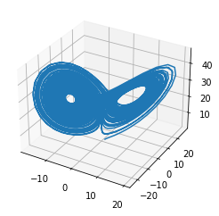

```python
lorenz_test_data = generate_lorenz_63(t_max=100)
plot_states(lorenz_test_data)
```

# Roessler System

Recall that the Roessler system in $\mathbb{R}^3$ is given by:

$$ \begin{align*} \dot{x} &= -y - z \\ \dot{y} &= x + ay \\ \dot{z} &= b + z(x - c) \end{align*} $$

where $a,\,b,\,c \in \mathbb{R}$ are parameters and $(x,\,y,\,z) \in \mathbb{R}^3$.

### Generating Data

We define a function to generate data for the Roessler system.

For simplicity, we make the default value for parameters $$ (a,\,b,\,c) = (0.2,\, 0.2,\, 5.7) $$ as used by Roessler.

Also for simplicity, we make initial conditions $$ (x_0,\,y_0,\,z_0) = (1,\,1,\,1) $$ the default value.

As with the Lorenz function, any set of parameters $(a,\,b,\,c)$ and initial conditions $(x,\,y,\,z)$ can be used by simply passing their values into the data generation function.

For sampling time, we simply adopt $$ \Delta t = 0.02 $$ as in the Lorenz example.

```python
def generate_roessler(params=[0.2, 0.2, 5.7], initial_state=[1, 1, 1],
                        del_t=0.02, t_max=10):
    '''
    Input:
    Output:
    '''

    # get (a, b, c) from params vector
    a, b, c = params

    # helper function for computing derivatives at each time iteration
    def f(state, t):
        '''
        Input: state vector in R3
        Output: derivative vector in R3 for L63 with passed parameters
        '''

        # get (x, y, z) components of the state vector
        x, y, z = state

        # return the value of the derivatives
        return (
            - y - z,
            x + a * y,
            b + z * (x - c)
        )

    # define length of simulation (time)
    T = np.arange(0, t_max, del_t)

    # integrate the system and return generated data
    return odeint(func = f, y0 = initial_state, t = T)
```

We test our code using the default parameter, initial state, and time increment choices, and `t_max=250` for simulation length.

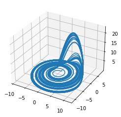

```python
roessler_test_data = generate_roessler(t_max=250)
plot_states(roessler_test_data)
```

# Autocorrelation

Let $X$ denote our generated data (e.g. from the L63 or Roessler system), that is, $$ X = \begin{bmatrix} x_0 \\ x_1 \\ \vdots \\ x_T \end{bmatrix} $$ is a $T \times 3$ matrix for some $T \in \mathbb{R}$ such that each row $x_t \in \mathbb{R}^3$ represents a state vector at time $t \in [0, T]$.

Then we know that the autocorrelation as a function of some time delay $l \in [0, T]$ in the $x-x$ domain is $$ R_{xx}(l) = \sum_{t=0}^{T} (x_{t} - \bar{x})(x_{t - l} - \bar{x}). $$ and similar definitions for $R_{xy},\,R_{xz},\,\dots$ etc. Note that we dropped the conjugate operator since our state vectors are in $\mathbb{R}^3$.

**Q:** What is the multiplication above when $x_t \in \mathbb{R}^3$?

We rely on `scipy.signal.correlate`, see here for documentation: https://docs.scipy.org/doc/scipy/reference/generated/scipy.signal.correlate.html

```python
def plot_autocorrelation(x, l, method="direct"):
    '''
    Inputs:     x: n-dimensional array
                l: time delay
    Output:
    '''

    # set some max delay, can be changed
    max_delay = len(x) / 5

    # first term in correlation
    x_p = x - np.mean(x)

    # compute lagged time series with zero padding
    x_lagged = np.zeros(len(x))
    # fill with time delay
    # x_lagged[i - l] = x_lagged[i]


    corr = scipy.signal.correlate(in1=x, in2=x, method=method)
    lags = scipy.signal.correlation_lags(len(x), len(x))

    # plot the autocorrelation as a function of time lag
    fig = plt.figure(facecolor="white")
    ax = plt.axes()
    ax.plot(lags, corr)
```

[figure not shown]

```python
plot_autocorrelation(lorenz_test_data)
```

```python
# export notebook
import os

os.system('jupyter nbconvert --to html data-generation.ipynb')
```